# D4 Tutorial: Reproducibly Accessing Census Data in R

Tyler Fricker & Jessica Godwin

August 8, 2024

# Introduction

## Why use U.S. Census data in climate research?

U.S. Census data is one of the predominate sources for information on **population size**, particularly when disaggregated by age, sex, race/ethnicity or other demographic and economic variables. Moreover, it is one of the only datasets providing. nationally-representative demographic and economic information on **households** and **housing units**. Data is collected every 10 years via the [Decennial Census of Population and Housing](https://www.census.gov/programs-surveys/decennial-census.html), but the [American Community Surve (ACS)](https://www.census.gov/programs-surveys/acs) is an annual survey of households designed to be nationally representative that collects more in-depth information about households and their members than the decennial Census.

It would be impossible to summarize the full array of questions asked in the ACS, but [one particularly relevant question](https://www.census.gov/acs/www/about/why-we-ask-each-question/migration/) is related to household member **migration**:

**Question 15a. Did this person live in this house or apartment 1 year ago? Possible answers:**

- Person is under 1 year old $\rightarrow$ *SKIP to question 16*
- Yes, this house $\rightarrow$ *SKIP to question 16*
- No outside the United States and Puerto Rico - *Print name of foreign country or U.S. Virgin Islands, Guam, etc. below then SKIP to question 16*
- No, different housein the United States or Puerto Rico.

**Question 15b. Where did this person live 1 year ago? Answer fields are: Address, Name of city, town, or post office, Name of U.S. county or municipio in Puerto Rico, Name of U.S. state or Puerto Rico, and ZIP Code.**

Other Census datasets include the [Population Estimates Program](https://www.census.gov/programs-surveys/popest.html) (annual post-censal population and housing units estimates for each state, county, and jurisdiction), the [Current Population Survey](https://www.census.gov/programs-surveys/cps.html) (ongoing surveys on household membership and labor force participation), and many datasets on economic indicators.

### Census geographies and uncertainty

Census data is available at a wide array of spatial resolution, and availability varies by data source. Figure 1 shows the hierarchy of Census geographies. Those geographies that can be built from the basic Census geographic unit, the Census block, like along the vertical **“geographic spine”**. Certain data products are also produced for some of the **“off-spine” geographies** in Figure 1.

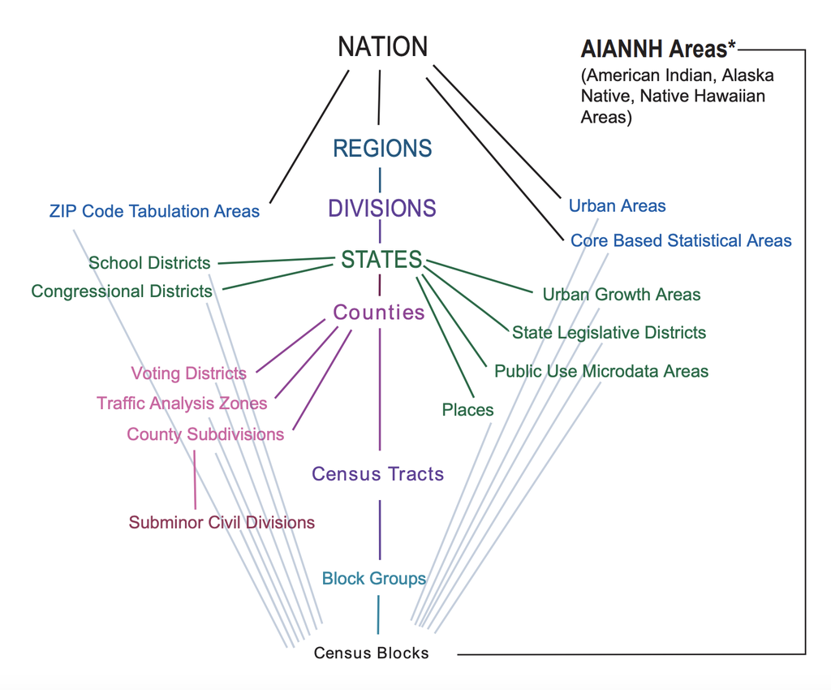

**Figure 1. Hierarchy of Census geographies.**

Decennial Census data is available at all geographies on the spine, but the introduction of **differential privacy** in the 2020 Decennial Census results in published counts that have more uncertainty at the smallest geographies of the spine. 2020 counts for the nation, states and large counties are reported with no uncertianty.

Aggregated, area-level ACS data is available annually at the national, state, and large county or city levels (65,000 or more). Uncertainty in these estimates arise from the **sampling variability** inherent in the household sampling scheme. Though data is collected annually, data is only shared publicly at the Census tract and block group level using 5-years of data. Sub-samples of ACS **microdata**, or person-level data, can be accessed for larger levels of geographies as well.

## Why access Census data with R or Python?

Many Census data tables are available for download as Excel files or .csv’s via the Census website and through [this interactive Census website](https://data.census.gov/table). However, accessing this data is not always reproducible. Moreover, you often need to download data for bigger geographic areas than may be of interest to you. Many packages and services exist to incorporate the downloading and accessing of specific variables for specific geographies into a reproducible workflow within R or Python. In addition, these packages often do much of the necessary “heavy-lifting” required to get the data into an easy-to-use format for other data science, GIS, or statistical programming tasks.

This tutorial will provide you with the necessary tools to access the Census data you need in a reproducible and simple way.

## Tutorial Outline

# Accessing Census Bureau Data with R Packages

## The Census API and `censusapi`

The [Census Application Programming Interface (API)](https://www.census.gov/data/developers/guidance/api-user-guide.html) is a tool built by the Census Bureau to allow for the downloading of public use Census data in an easy and systematic way. The Census API can be queried by anyone with the internet and a **Census API Key** (a unique-to-you alphanumeric code issued by the Census Bureau). It is constructed so you can specify the dataset and year you want, the specific variables you want within that dataset, and the geography for which you want the information within a formulaic URL in a relatively intuitive way. (See [examples](https://www.census.gov/data/developers/guidance/api-user-guide.Example_API_Queries.html#list-tab-559651575).) Though you can type these URLs into your internet browser, using functions within R or Python to visit certain URLs that query the API allow for a reproducible workflow. [This online Census Bureau course](https://www.census.gov/data/academy/courses/intro-to-the-census-bureau-data-api.html#1) is useful for those interested in learning more about the Census API

The `censusapi` package ([CRAN](https://cran.r-project.org/web/packages/censusapi/index.html), [GitHub](https://github.com/hrecht/censusapi), [Author website](https://www.hrecht.com/censusapi/)) is an R package written and maintained by [Hannah Recht](https://www.hrecht.com/) that provides a suite of functions that facilitate the construction and implementation of Census API URL queries for more than 1,500 Census API endpoints. This package is an incredible tool, but there are better options if you are mainly interested in decennial Census and ACS data.

## `tidycensus`

The `tidycensus` package ([CRAN](https://cran.r-project.org/package=tidycensus), [GitHub](https://github.com/walkerke/tidycensus), [Author website](https://walker-data.com/tidycensus/#)) is an R package written and maintained by [Kyle Walker](https://walker-data.com/). The package provides access to tabular decennial Census, ACS, ACS Migration Flows, and Population Estimates datasets at both on- and off-spine Census geographies. In addition to taking care of the logistics of querying the API for you with easy-to-use functions, the `tidycensus` package wrangles the data into a nice format, providing spatial data objects when requested.

The remainder of this tutorial will focus on using `tidycensus`.

## Getting and managing your Census API key

To use either the `censusapi` or `tidycensus` packages you need to [request your Census API key](http://api.census.gov/data/key_signup.html). This process is quick! Your own personal API key will be delivered to the email address provided.

One challenge with using these packages in a reproducible and group-based workflow is the management of API keys. Each member of the team who will be using any code that queries the Census APIs needs *their own API key*. API keys are not meant to be shared.

One nice work around is to have everyone in a group create their own R script such as the file CensusAPIKey.R in Figure 2. This purpose will assign an individual’s Census API code to a character object with a common name. In this example, everyone’s API character string is assigned to an object called `myKey`.

[figure not shown]

**Figure 2. Example of way to store your Census API key as a character object in R.**

When initializing your group’s GitHub repository, add the name of this file to your `.gitignore` file as in Figure 3. **NB: It’s best to do this before adding the CensusAPIKey.R to your repository.**

[figure not shown]

**Figure 3. Adding your API key script to the .gitignore file**

Once your `.gitignore` is modified and pushed, every team member can have their own CensusAPIKey.R file on their own machine that is never pushed to GitHub. Your team’s code can be written in such a way that if CensusAPIKey.R is sourced in a script, every time an API key is needed a reference to the object `myKey` will be sufficient regardless of which team member is executing code. See example using `tidycensus` below.

```r
## Example works when CensusAPIKey.R is stored in
## the same filepath as the .R script being ran
## pointed to by rstudioapi::getActiveDocumentContext()$path

# Setup ####
## setwd() ####
setwd(dirname(rstudioapi::getActiveDocumentContext()$path))

## Libraries ####
library(tidycensus)

### Source Census API Key ####
source("CensusAPIKey.R")
### Set session API key in tidycensus ####
census_api_key(key = myKey)
```

# Using `tidycensus`

The `tidycensus` package is superbly developed and maintained. Moreover, Kyle Walker has developed [so much material](https://walker-data.com/tidycensus/articles/) to aid `tidycensus` users including an entire textbook, [Analyzing US Census Data: Methods, Maps, and Models in R](https://walker-data.com/census-r/index.html). For questions not answered in this tutorial, this book is a great place to start.

## Selecting variables and tables

To access Census data via `tidycensus` you need to know the following information:

- the dataset,
- the dataset-specific variable name,
- the annual timeframe for which you want data,
- the geographic level for which you want data, and
- the temporal scale for which you want data (ACS only: 1-year or 5-year),
- your Census API key.

In the subsections below, we briefly discuss the selection process and how it relates to the `tidycensus` functions for querying Census APIs briefly. Following that, we provide full start-to-finish examples of querying both the decennial Census and ACS.

### Datasets

The dataset you use will determine the name of the `tidycensus` function used to query the Census API.

One access decennial Census data via the `get_decennial()` function and ACS data via the `get_acs()` function.

### Variable & table names

In `tidycensus` variables can be identified in the output of the `load_variables()` function by their `name`, `label`, and `concept`. A `concept` such as `SEX BY AGE` below is shared by many variables each of which are uniquely identified by an alphanumeric string, or their `name`. Variables are also uniquely identified by the combination of their `label` and their `concept`.

In the example below, all variables in the 2021 ACS within the `SEX BY AGE` `concept` have a `name` that begins with `B01001`. These variables contain estimates and margins of error for population counts by sex (Male, Female) and age categories (0-5, 5-9, 10-14, 15-17, 18-19, 20, 21, 22-24, 25-29, 30-34, 35-39, 40-44, 45-49, 50-54, 55-59, 60-61, 62-64, 65-66, 67-69, 70-74, 75-79, 80-84, and 85+.) Totals are provided for each sex and the population overall (e.g. `B01001_001` and `B01001_002` below.)

```r
load_variables(year = 2021, dataset = "acs1") %>%
  filter(concept == "SEX BY AGE") %>% head()
```

```
## # A tibble: 6 × 3
##   name       label                                   concept
##   <chr>      <chr>                                   <chr>
## 1 B01001_001 Estimate!!Total:                        SEX BY AGE
## 2 B01001_002 Estimate!!Total:!!Male:                 SEX BY AGE
## 3 B01001_003 Estimate!!Total:!!Male:!!Under 5 years  SEX BY AGE
## 4 B01001_004 Estimate!!Total:!!Male:!!5 to 9 years   SEX BY AGE
## 5 B01001_005 Estimate!!Total:!!Male:!!10 to 14 years SEX BY AGE
## 6 B01001_006 Estimate!!Total:!!Male:!!15 to 17 years SEX BY AGE
```

A variable’s `name` is passed as a character string to the `variables` argument of the `get_acs()` or `get_decennial()` functions, e.g. `variables = "B01001_001"`. A character vector can be passed if you would like to select more than one variable in the same API query, e.g. `variables = c("B01001_001", "B01001_002")`.

There is also a `table` argument that allows you to select all variables from the same `concept`. For example, to select all variables from the `SEX BY AGE` concept, one would specify `table = "B01001"` and not specify anything for the `variable` argument.

### Data Year

Both `get_acs()` and `get_decennial()` have a `year` argument. For the decennial Census and ACS 1-year data, the argument is simply the year for which you want data. However, for ACS 5-year data, the `year` argument still takes only one value and that value is the *endpoint* of the 5-year interval. For example, specifying `year = 2019` for ACS 5-year data will return estimates produced using ACS data collected in years 2015-2019.

### Geographic scale

Both `get_decennial()` and `get_acs()` require one to specify the `geography` argument indicating the geographic level (e.g. `national`, `county`, `tract`, etc.) at which data is requested. The [`tidycensus` Basic Usage vignette](https://walker-data.com/tidycensus/articles/basic-usage.html#geography-in-tidycensus) contains a list of the Census geographies and how they should be specified in `tidycensus`

### Temporal scale

Once you know your dataset of interest AND your geographic scale of interest, you are ready to specify your temporal scale.

If you are using the *decennial Census*, you will be requesting data at the single year scale regardless of your `geography`. In the `get_decennial()` function you must set your `sumfile` argument to the appropriate Census summary file for that year (2000, 2010, or 2020). Find appropriate `sumfile` arguments for each decennial Census in [Section 2.1.1.1 of Kyle Walker’s book](https://walker-data.com/census-r/an-introduction-to-tidycensus.html#decennial-census).

If you are using the *ACS*, you will be requesting data at either the 1-year or 5-year scale *depending upon your choice of `geography`*. In the `get_acs()` function you must set your `survey` argument to either `acs1` for 1-year data or `acs5` for 5-year data. For national, state, and large counties or cities (Census places), you can usually specify `survey = "acs1"`. For small counties or places, tracts, or block groups you will almost certainly need to specify `survey = "acs5"`. However, even at the state or county level, there may be some variables, e.g. population counts by age, sex, and race for a race category in the Census, that have a small count in that area and will require the use of 5-year data.

## `get_decennial()`

Below we provide code for pulling counts of total housing units for each county in the state of Washington from the 2020 decennial Census using the following information:

- the dataset: `sumfile = pl`,
- the dataset-specific variable name: total housing units `variables = "H1_001N"`,
- the annual timeframe: `year = 2020`,
- the geographic level: `geography = "county"` and `state = "WA"`,
- the temporal scale: using decennial data, so there’s no argument to specify
- your Census API key: `key = mykey`.

```r
hu_wa_2020 <- get_decennial(geography = "county",
                            variables = "H1_001N",
                            year = 2020,
                            sumfile = "pl",
                            state = "WA",
                            key = myKey)
```

```
## Using the PL 94-171 Redistricting Data Summary File
```

```
## Note: 2020 decennial Census data use differential privacy, a technique that
## introduces errors into data to preserve respondent confidentiality.
## ℹ Small counts should be interpreted with caution.
## ℹ See https://www.census.gov/library/fact-sheets/2021/protecting-the-confidentiality-of-the-2020-census-redistricting-data.html for additional guidance.
```

```r
head(hu_wa_2020)
```

```
## # A tibble: 6 × 4
##   GEOID NAME                       variable  value
##   <chr> <chr>                      <chr>     <dbl>
## 1 53001 Adams County, Washington   H1_001N    6735
## 2 53003 Asotin County, Washington  H1_001N   10034
## 3 53005 Benton County, Washington  H1_001N   80076
## 4 53007 Chelan County, Washington  H1_001N   37267
## 5 53009 Clallam County, Washington H1_001N   37930
## 6 53011 Clark County, Washington   H1_001N  195036
```

### `GEOID`s

The `GEOID` column of output includes the standard Census numeric code for a particular geography. States and counties are determined by their [Federal Information Processing Series(FIPS) codes](https://www.census.gov/library/reference/code-lists/ansi.html).

The **state** code is 2 digits long, Washington’s FIPS code is 53, and we see each `GEOID` above begins with those digits.

The **county** code within each state is 3 digits long. Adams County’s unique code within Washington is 001. So, the full `GEOID` for Adams County, Washington is 53001.

The **tract** code that uniquely identifies a Census tract within a county is 6 digits long. The resulting `GEOID` for a tract in Adams County, Washington is then 53001TTTTTT, where TTTTTT represents a 6-digit tract code.

The **block group** code that uniquely identifies each Census block group within a certain Census tract, TTTTTT, within Adams County, Washington is 1 digit long. The resulting `GEOID` for a block group within tract TTTTTT in Adams County, Washington is 53001TTTTTTG, where G represents a 1 digit tract code.

The **block** code that uniquely identifies each Census block within a block group, G, within a certain Census tract, TTTTTT, within Adams County, Washington is 3 digits long. The resulting `GEOID` for a block group within tract TTTTTT and block group G in Adams County, Washington is 53001TTTTTTGBBB, where BBB represents a 3 digit tract code.

## `get_acs()`

```r
pop_sex_king_2021 <- get_acs(geography = "county",
                            variables = c("B01001_002", "B01001_026"),
                            year = 2021,
                            survey = "acs1",
                            state = "WA",
                            county = "King",
                            key = myKey)
```

```
## The 1-year ACS provides data for geographies with populations of 65,000 and greater.
```

```r
head(pop_sex_king_2021)
```

```
## # A tibble: 2 × 5
##   GEOID NAME                    variable   estimate   moe
##   <chr> <chr>                   <chr>         <dbl> <dbl>
## 1 53033 King County, Washington B01001_002  1140802   552
## 2 53033 King County, Washington B01001_026  1111503   552
```

While the output of `get_decennial()` only has a fourth column called `value` after `GEOID`, `NAME`, and `variable`, ACS output has two columns: `estimate` and `moe`.

**NB: The `moe` represents the whole margin of error for a 90% (by default) confidence interval (CI). In other words, estimate + moe will give you the upper limit of a 90% CI and estimate - moe will give you the lower limit.**

To calculate the standard error for each estimate when the default 90% margin of error is used, use the following code:

```r
pop_sex_king_2021 <- pop_sex_king_2021 %>%
  mutate(se = moe/qnorm(.95))
```

Below we provide code for pulling counts of individuals by sex and age for King County, Washington from the 2021 ACS using the following information:

- the dataset: ACS,
- the dataset-specific variable name: all variables in the concept “SEX BY AGE” `table = "B01001"`,
- the annual timeframe: `year = 2021`,
- the geographic level: `geography = "county"` and `state = "WA"` and `county = "King"`,
- the temporal scale: using ACS data at county level, let’s use 1-year data `survey = "acs1"`
- your Census API key: `key = mykey`.

**NB: If we wanted info for a county with a population less than 65,000 we would need to get 5-year data for 2017-2021 using `survey = "acs5"`.**

```r
pop_sex_age_king_2021 <- get_acs(geography = "county",
                                 table = "B01001",
                                 year = 2021,
                                 survey = "acs1",
                                 state = "WA",
                                 county = "King",
                                 key = myKey)
```

```
## The 1-year ACS provides data for geographies with populations of 65,000 and greater.
```

```
## Loading ACS1 variables for 2021 from table B01001. To cache this dataset for faster access to ACS tables in the future, run this function with `cache_table = TRUE`. You only need to do this once per ACS dataset.
```

```r
head(pop_sex_age_king_2021)
```

```
## # A tibble: 6 × 5
##   GEOID NAME                    variable   estimate   moe
##   <chr> <chr>                   <chr>         <dbl> <dbl>
## 1 53033 King County, Washington B01001_001  2252305    NA
## 2 53033 King County, Washington B01001_002  1140802   552
## 3 53033 King County, Washington B01001_003    61208   521
## 4 53033 King County, Washington B01001_004    62450  3251
## 5 53033 King County, Washington B01001_005    66507  3251
## 6 53033 King County, Washington B01001_006    37342   367
```

## Dealing with variable labels

Now that we’ve walked through querying the Census API for the decennial Census and the ACS via `tidycensus` we need to cover some basics to make this data more usable. First, and foremost, no one will ever be able to remember what every alphanumeric Census variable `name` is by heart. But, if we use the output of `load_variables()` coupled with some data-wrangling, we can get neat string labels in no time!

**Step 1: Save the output of `load_variables()`**

```r
acs_vars_2021 <- load_variables(year = 2021, dataset = "acs1")
head(acs_vars_2021)
```

```
## # A tibble: 6 × 3
##   name        label                                   concept
##   <chr>       <chr>                                   <chr>
## 1 B01001A_001 Estimate!!Total:                        SEX BY AGE (WHITE ALONE)
## 2 B01001A_002 Estimate!!Total:!!Male:                 SEX BY AGE (WHITE ALONE)
## 3 B01001A_003 Estimate!!Total:!!Male:!!Under 5 years  SEX BY AGE (WHITE ALONE)
## 4 B01001A_004 Estimate!!Total:!!Male:!!5 to 9 years   SEX BY AGE (WHITE ALONE)
## 5 B01001A_005 Estimate!!Total:!!Male:!!10 to 14 years SEX BY AGE (WHITE ALONE)
## 6 B01001A_006 Estimate!!Total:!!Male:!!15 to 17 years SEX BY AGE (WHITE ALONE)
```

**Step 2: Join `load_variables()` output with `get_*()` output** Below, we join `acs_vars_2021` onto `pop_sex_age_king_2021` by the respective variable name column in each dataset. This still leaves the pesky issue of the “!!” and “:” in the label strings.

```r
pop_sex_age_king_2021 <- pop_sex_age_king_2021 %>%
  left_join(acs_vars_2021 %>%
              select(name, label),
            by = c("variable" = "name")) %>%
  relocate("label", .after = "variable")

head(pop_sex_age_king_2021)
```

```
## # A tibble: 6 × 6
##   GEOID NAME                    variable   label                  estimate   moe
##   <chr> <chr>                   <chr>      <chr>                     <dbl> <dbl>
## 1 53033 King County, Washington B01001_001 Estimate!!Total:        2252305    NA
## 2 53033 King County, Washington B01001_002 Estimate!!Total:!!Mal…  1140802   552
## 3 53033 King County, Washington B01001_003 Estimate!!Total:!!Mal…    61208   521
## 4 53033 King County, Washington B01001_004 Estimate!!Total:!!Mal…    62450  3251
## 5 53033 King County, Washington B01001_005 Estimate!!Total:!!Mal…    66507  3251
## 6 53033 King County, Washington B01001_006 Estimate!!Total:!!Mal…    37342   367
```

**Step 3: Clean up the variable labels** How you want to do this will vary for each concept, this specific example is appropriate for the “SEX BY AGE” concept. The result of this code is extra `sex` and `age` columns added to the ACS data making it easier to plot and analyze.

```r
 pop_sex_age_king_2021 <- pop_sex_age_king_2021 %>%
  ## Replace the starting "Estimate!!Total:"
  ## with an empty string everywhere
  mutate(label = gsub("Estimate!!Total:", "", label),
  ## Replace all remaining !!
         label = gsub("!!", "", label)) %>%
  ## The only special characters left now are the :
  ## between sex and age groups
  ## we will split the string in each row on the :
  ## and retain the first element for sex and the second for label
  group_by(variable) %>%
  mutate(sex = unlist(strsplit(label, ":"))[1],
         age = unlist(strsplit(label, ":"))[2]) %>%
  ungroup() %>%
  ## Fill in "Total" strings where sex or age are missing
  mutate(sex = ifelse(is.na(sex), "Total", sex),
         age = ifelse(is.na(age), "Total", age)) %>%
  relocate(c("sex", "age"), .after = "label")

## Check our work
pop_sex_age_king_2021 %>%
  select(variable, label, sex, age) %>%
  head()
```

```
## # A tibble: 6 × 4
##   variable   label                 sex   age
##   <chr>      <chr>                 <chr> <chr>
## 1 B01001_001 ""                    Total Total
## 2 B01001_002 "Male:"               Male  Total
## 3 B01001_003 "Male:Under 5 years"  Male  Under 5 years
## 4 B01001_004 "Male:5 to 9 years"   Male  5 to 9 years
## 5 B01001_005 "Male:10 to 14 years" Male  10 to 14 years
## 6 B01001_006 "Male:15 to 17 years" Male  15 to 17 years
```

# Getting results